# Data Report of Forest Fires in Brazil

Xinhe Kang

2020/2/21

## Data Pre-Processing

Packages needed:

```r
library(ggplot2)
library(RColorBrewer)
library(dplyr)
library(forecast)
library(plotly)
```

```r
data <- data[-c(3109:3347), ]
str(data)
```

```
## 'data.frame':    6215 obs. of  5 variables:
##  $ year  : int  1998 1999 2000 2001 2002 2003 2004 2005 2006 2007 ...
##  $ state : Factor w/ 34 levels "Acre","Alagoas",..: 1 1 1 1 1 1 1 1 1 1 ...
##  $ month : Factor w/ 214 levels "0","1.008","1.322",..: 207 207 207 207 207 207 207 207 207 207 ...
##  $ number: Factor w/ 1390 levels "0","1","1.001",..: 1 1 1 1 1 268 1 301 853 1 ...
##  $ date  : Factor w/ 21 levels "","1998/1/1",..: 2 3 4 5 6 7 8 9 10 11 ...
```

```r
summary(data)
```

```
##       year              state           month          number
##  Min.   :1998   Rio        : 717   January : 521   0      : 607
##  1st Qu.:2002   Mato Grosso: 478   April   : 520   1      : 237
##  Median :2007   Paraiba    : 478   August  : 520   2      : 173
##  Mean   :2007   Alagoas    : 240   Feburary: 520   3      : 142
##  3rd Qu.:2012   Acre       : 239   July    : 520   4      : 112
##  Max.   :2017   Amapa      : 239   June    : 520   5      :  93
##                 (Other)    :3824   (Other) :3094   (Other):4851
##        date
##  1998/1/1: 312
##  1999/1/1: 312
##  2000/1/1: 312
##  2001/1/1: 312
##  2002/1/1: 312
##  2003/1/1: 312
##  (Other) :4343
```

## Relationship Visualization

In this part, we are exploring the relationship between the number of forest fires and either year, state or month.

### Relationship between number and state

Since this dataset is inappropriately ordered, if we want to analyze the relationship between two variables, it is essential to rearrange it using for loop.

```r
st_num <- data.frame(No = c(1:22),
                     state = unique(data$state),
                     number = rep(0, 22))
head(st_num, 6)
```

```
##   No    state number
## 1  1     Acre      0
## 2  2  Alagoas      0
## 3  3    Amapa      0
## 4  4 Amazonas      0
## 5  5    Bahia      0
## 6  6    Ceara      0
```

```r
for (i in 1:22) {
  f <- filter(data, data$state == st_num$state[i])
  s <- sum(f$number)
  st_num$number[i] <- s
}
head(st_num, 6)
```

```
##   No    state number
## 1  1     Acre  18452
## 2  2  Alagoas   4644
## 3  3    Amapa  21831
## 4  4 Amazonas  30636
## 5  5    Bahia  44718
## 6  6    Ceara  30415
```

We first create an empty data frame with three columns, in which all of the numbers are 0. Then we write a for loop to aggregate all of the values of each state in Brazil and assign each outcome to the relevant location.

Then let’s make a plot.

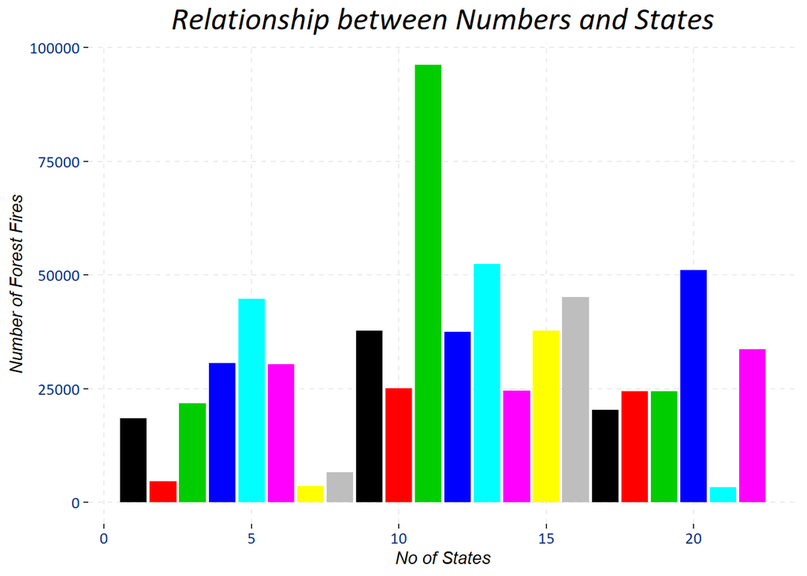

### Relation between numbers and months

Silimarly, before exploring the relationship between numbers and months, we need create an empty data frame to store data. However, it is important to note that we also need to define the levels of factors in both the data and the empty data frame we just create, or the months will be in alphabetical order. Then we create another for loop.

```r
mo_num <- data.frame(month = c("January", "Feburary", "March", "April", "May", "June",
                               "July", "August", "September", "October", "November",
                               "December"),
                     number = rep(0, 12))
mo_num$month <- factor(mo_num$month,
                       levels = c("January", "Feburary", "March", "April", "May", "June",
                                  "July", "August", "September", "October", "November",
                                  "December"))

data$month <- factor(data$month,
                     levels = c("January", "Feburary", "March", "April", "May", "June",
                                "July", "August", "September", "October", "November",
                                "December"))

for (i in 1:12) {
  f <- filter(data, data$month == mo_num$month[i])
  s <- sum(f$number)
  mo_num$number[i] <- s
}
head(mo_num)
```

```
##      month number
## 1  January  42429
## 2 Feburary  29321
## 3    March  30023
## 4    April  27835
## 5      May  33981
## 6     June  52337
```

Let’s make a plot.

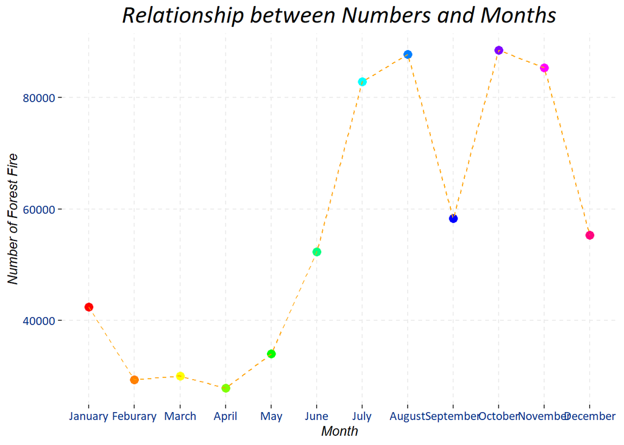

The seasonal trend is obvious in this plot. Less fire occurs from Feburary to May, and most fire happens in July, August, October and November. However, September has a relatively low number of forest fire. This author guesses it is either because of the data has some incorrect values, or because of the climate.

### Relationship between years

Following the previous steps, we can do this easily.

```r
ye_num <- data.frame(year = unique(data$year),
                     number = rep(0, 20))

for (i in 1:20) {
  f <- filter(data, data$year == ye_num$year[i])
  s <- sum(f$number)
  ye_num$number[i] <- s
}
head(ye_num)
```

```
##   year number
## 1 1998  19286
## 2 1999  24678
## 3 2000  26549
## 4 2001  28223
## 5 2002  36106
## 6 2003  41667
```

Let’s make a plot.

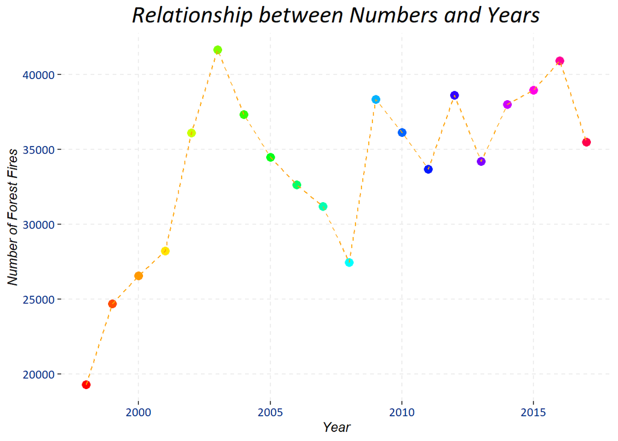

We can also find a cyclical trend in this plot, and the entire trend goes up.

## Time Seires

We choose Mato Grosso to analyze, which has the largest amount of forest fires.

Then we create an empty data frame which consists of year and twelve months (13 columns in total). Remember to convert the names into factors.

```r
matts <- data.frame(year = c(1998:2017),
                    January = rep(0),
                    Feburary = rep(0),
                    March = rep(0),
                    April = rep(0),
                    May = rep(0),
                    June = rep(0),
                    July = rep(0),
                    August = rep(0),
                    September = rep(0),
                    October = rep(0),
                    November = rep(0),
                    December = rep(0))
colnames(matts) <- factor(colnames(matts))
rownames(matts) <- factor(rownames(matts))
head(matts)
```

```
##   year January Feburary March April May June July August September October
## 1 1998       0        0     0     0   0    0    0      0         0       0
## 2 1999       0        0     0     0   0    0    0      0         0       0
## 3 2000       0        0     0     0   0    0    0      0         0       0
## 4 2001       0        0     0     0   0    0    0      0         0       0
## 5 2002       0        0     0     0   0    0    0      0         0       0
## 6 2003       0        0     0     0   0    0    0      0         0       0
##   November December
## 1        0        0
## 2        0        0
## 3        0        0
## 4        0        0
## 5        0        0
## 6        0        0
```

Next, let’s use a for loop to assign each value.

```r
for (i in 1:20) {
  for (j in 1:12) {
    temp <- filter(mat, mat$year == matts$year[i])
    mo <- filter(temp, temp$month == colnames(matts)[j+1])
    matts[i, j+1] <- sum(mo$number)
  }
}
head(matts)
```

```
##   year January Feburary March April  May June July August September
## 1 1998       0        0     0     0    0   84  363    243       467
## 2 1999     278       97   118   173  937  129    4     22        13
## 3 2000     370      116    83   149  128  161  161    536       516
## 4 2001     141      143    63   417  113  255  592      9         9
## 5 2002     476      120   218   871   90  524  940     17        13
## 6 2003    1078      700   691  1029 1016  174  187    964        16
##   October November December
## 1     578      488      176
## 2       8      843      353
## 3     663      776      237
## 4     569      593      180
## 5      11        3      377
## 6     546      382      154
```

It is time to create a time series data frame

```r
ts <- ts(matts2, start = c(1998, 1), frequency = 12)
ts
```

```
##       Jan  Feb  Mar  Apr  May  Jun  Jul  Aug  Sep  Oct  Nov  Dec
## 1998    0    0    0    0    0   84  363  243  467  578  488  176
## 1999  278   97  118  173  937  129    4   22   13    8  843  353
## 2000  370  116   83  149  128  161  161  536  516  663  776  237
## 2001  141  143   63  417  113  255  592    9    9  569  593  180
## 2002  476  120  218  871   90  524  940   17   13   11    3  377
## 2003 1078  700  691 1029 1016  174  187  964   16  546  382  154
## 2004  559  441  968  538   27  403  540   14   26  969  210  111
## 2005  497 1092  520  498  329  441  863   15   21  654  160  292
## 2006 1006  487  585  212  368  945  290    7   13  246   84   41
## 2007  495  324  613  125  421  142  198   15   29  672  381   96
## 2008  308  258  277  346  153  427  117  458    8  438  240  367
## 2009  756  412  443  460 1443 1355  355  818    4  856 1027  258
## 2010  370  588  754  905  106  150  592   15   19  601 1027 1122
## 2011  300  180  289  368  628 1078  251  554    7  278  446 1008
## 2012  367  305  592  618  969   97  540    8   12  654  490  686
## 2013  443  475  721  416  811   36  202  680    6  379  424  642
## 2014  512  338  750  988 1003   85  195  319  372  586  191  550
## 2015 1186  690  895 1012  599  300  372    6   12  513  277  395
## 2016  501  188  144  162   98  121  690    7   10    3 1176  548
## 2017  837  502  889  665  917  177    3    7   25  689  946    0
```

### Analysis 1: Simple Moving Average

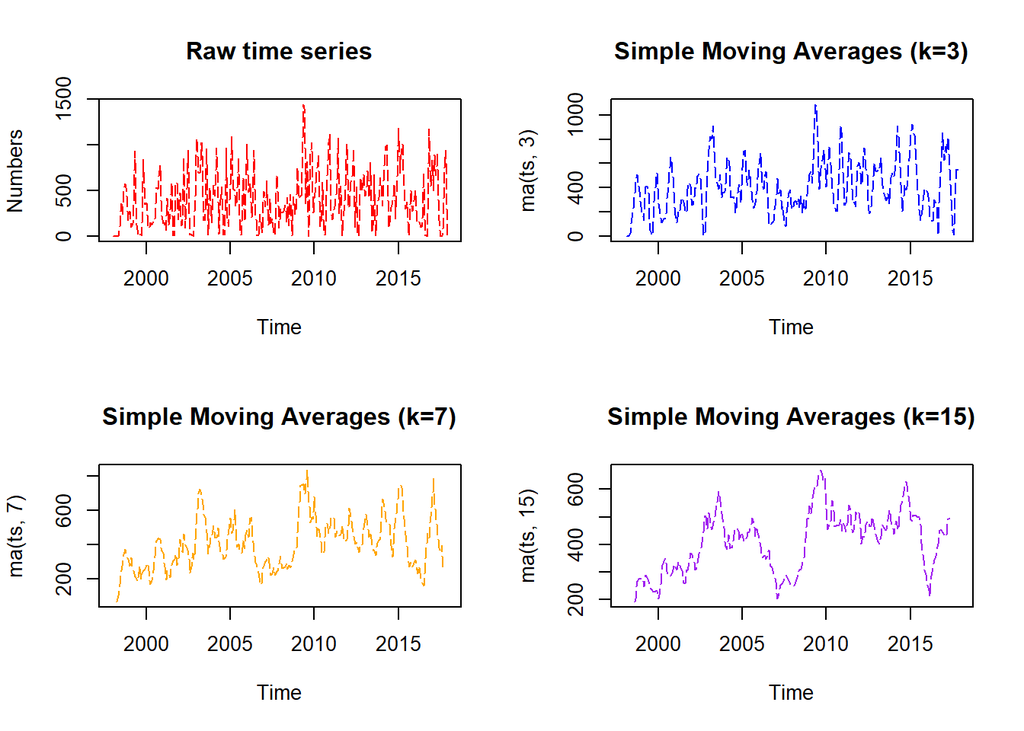

```r
opar <- par(no.readonly=TRUE)
par(mfrow=c(2,2))
plot(ts, main="Raw time series", col = "red", lty = 5)
plot(ma(ts, 3), main = "Simple Moving Averages (k=3)", col = "blue", lty = 5)
plot(ma(ts, 7), main = "Simple Moving Averages (k=7)", col = "orange", lty = 5)
plot(ma(ts, 15), main = "Simple Moving Averages (k=15)", col = "purple", lty = 5)
```

```r
par(opar)
```

### Analysis 2: Visualization

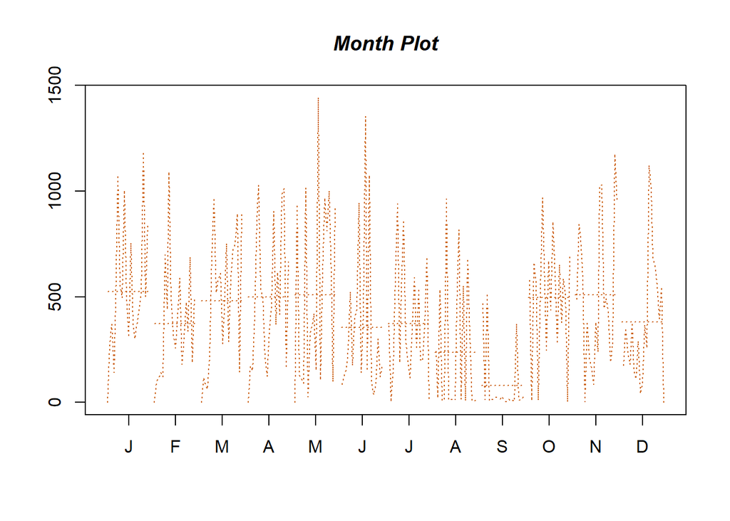

```r
monthplot(ts, ylab = "", col = "chocolate3", lty = 3, lwd = 1)
title(main="Month Plot", font.main=4)
```

We can see from the plot above that there is large difference on the amount of forest fires among years, but smaller among months. To be specific, on avergae, half of the months remain a stable level of 500 times. September has the lowest number of forest fires, followed by August. Four months (Feb, June, July, December) also remain a stable level of 300 - 400 times.

We choose two subsets to make two seasonal plots (1998-2002 & 2013-2017)

[figure not shown]

```r
ts_98_02 <- window(ts, start=c(1998, 1), end=c(2002, 12))
ts_13_17 <- window(ts, start=c(2013, 1), end=c(2017, 12))

seasonplot(ts_98_02, main = "", xlab = "", ylab = "",
           col = c("coral4", "cadetblue1", "chartreuse1", "chocolate1", "brown3"),
           lty = 5, lwd = 1, pch = 20, cex = 1)
title(main="Seasonal Plot of 1998 - 2000", font.main=4)
legend("topleft", legend = c("1998", "1999", "2000", "2001", "2002"),
       col = c("coral4", "cadetblue1", "chartreuse1", "chocolate1", "brown3"),
       cex = 0.7, bty = "n", lty = 5, pch = 20)
```

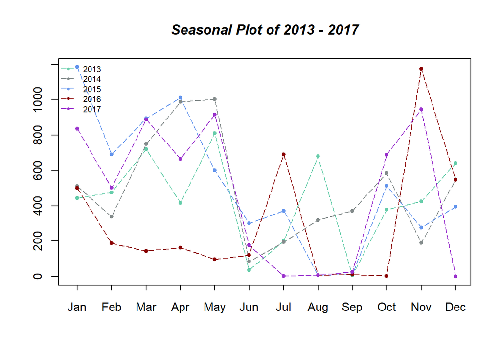

```r
seasonplot(ts_13_17, main = "", xlab = "", ylab = "",
           col = c("aquamarine3", "azure4", "cornflowerblue", "darkred", "darkorchid3"),
           lty = 5, lwd = 1, pch = 20, cex = 1)
title(main="Seasonal Plot of 2013 - 2017", font.main=4)
legend("topleft", legend = c("2013", "2014", "2015", "2016", "2017"),
       col = c("aquamarine3", "azure4", "cornflowerblue", "darkred", "darkorchid3"),
       cex = 0.7, bty = "n", lty = 5, pch = 20)
```

We can summarize from the two plots above that there is some similar seasonal trend between two and three years. For example, similar number of forest fires occurred from January to September in 2001 and 2002. Also, the years of 1998 and 2000 show a similar trend for the whole year. In the second plot, 2013, 2014, 2015 and 2017 all have a higher number of forest firesfrom Feburary to May, and they all go down in June.

Finally, in order to have a direct insight on the locations of the cities where more forest fires occurred, I chose top 10 cities that have the largest numbers of forest fires, and make a map. Since the package “REmap” cannot be installed in this computer, which is used for automatically getting the locations, I just input the latitudes and longtitudes in person. Moreover, RMarkdown does not support dynamic plots, so I can only assert the picture in the report.

```r
arr <- arrange(st_num, desc(st_num$number))[1:10,]
arr <- data.frame(arr,
                  lat = c(-16.350000, -22.158470, -23.533773, -22.908333,
                          -11.409874, -21.508900, -16.328547, -19.841644,
                          -21.175000, -3.416843),
                  lon = c(-56.666668, -43.293210, -46.625290, -43.196388,
                          -41.280857, -43.322800, -48.953403, -43.986511,
                          -43.017780, -65.856064))
arr
```

```
##    No        state number        lat       lon
## 1  11  Mato Grosso  96178 -16.350000 -56.66667
## 2  13      Paraiba  52432 -22.158470 -43.29321
## 3  20    Sao Paulo  51118 -23.533773 -46.62529
## 4  16          Rio  45160 -22.908333 -43.19639
## 5   5        Bahia  44718 -11.409874 -41.28086
## 6  15         Piau  37777 -21.508900 -43.32280
## 7   9        Goias  37677 -16.328547 -48.95340
## 8  12 Minas Gerais  37453 -19.841644 -43.98651
## 9  22    Tocantins  33675 -21.175000 -43.01778
## 10  4     Amazonas  30636  -3.416843 -65.85606
```

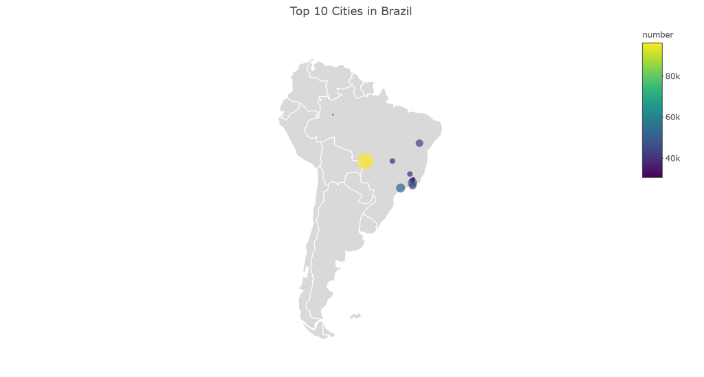

```r
g <- list(
  scope = 'south america',
  showland = TRUE,
  landcolor = toRGB("gray85"),
  subunitwidth = 1,
  countrywidth = 1,
  subunitcolor = toRGB("white"),
  countrycolor = toRGB("white")
)
p <- plot_geo(arr, sizes = c(1, 250)) %>%
  add_markers(
    x = ~lon, y = ~lat, size = ~number, color = ~number, hoverinfo = "text",
    text = ~paste(arr$state, ",", arr$number)
  ) %>%
  layout(title = 'Top 10 Cities in Brazil', geo = g)
```

## Conclusions

1.Mato Grosso, Paraiba, Sao Paulo and Rio need to pay particular attention to the forest fires. There might be some factors and reasons, but they need to come up with effective solutions to all of the problems.

2.Less forest fires occur between January to May, but more in July, Augest, October and November.That might be because it is relatively dry in winter and relatively wet in summer. More emergency solutions need to be arranged in winter, especially in these four months.

3.The trend among years goes up gradually, thus, the government has to focus on this.

### That’s All. Thanks for Reading!